# Exercise 1 - Getting started with data science

Ng Jian Long

Assignments for the course focus on practical aspects of the concepts covered in the lectures. Assignments are based on the material covered in James et al. You will start working on the assignment in the lab sessions after the lectures, but may need to finish them after class. If you do not get through the whole assignment, do not worry!

## 1. Working with a sample dataset

This exercise relates to the `College` data set, which can be found in the file `College.csv` on the website for the main course textbook (James et al 2013) http://faculty.marshall.usc.edu/gareth-james/ISL/data.html. It contains a number of variables for 777 different universities and colleges in the US.

The variables are:  
* `Private` : Public/private indicator  
* `Apps` : Number of applications received  
* `Accept` : Number of applicants accepted  
* `Enroll` : Number of new students enrolled  
* `Top10perc` : New students from top 10% of high school class  
* `Top25perc` : New students from top 25% of high school class  
* `F.Undergrad` : Number of full-time undergraduates  
* `P.Undergrad` : Number of part-time undergraduates  
* `Outstate` : Out-of-state tuition  
* `Room.Board` : Room and board costs  
* `Books` : Estimated book costs  
* `Personal` : Estimated personal spending  
* `PhD` : Percent of faculty with Ph.D.’s  
* `Terminal` : Percent of faculty with terminal degree  
* `S.F.Ratio` : Student/faculty ratio  
* `perc.alumni` : Percent of alumni who donate  
* `Expend` : Instructional expenditure per student  
* `Grad.Rate` : Graduation rate

Before reading the data into R, it can be viewed in Excel or a text editor, if you find that convenient.

### 1.1 Load the data

Use the `read.csv()` function to read the data into `R`. Call the loaded data `college`. Make sure that you have the directory set to the correct location for the data. You can load this in R directly from the website, using:

```r
library(ISLR)

#Loading Data
college <- read.csv("College.csv")
```

### 1.2 View the data

Look at the data using the `View()` function. You should notice that the first column is just the name of each university. We don’t really want R to treat this as data. However, it may be handy to have these names for later. Try the following commands:

```r
row.names <- college[, 1]
rownames(college) <- row.names
View(college)
```

You should see that there is now a `row.names` column with the name of each university recorded. This means that R has given each row a name corresponding to the appropriate university. R will not try to perform calculations on the row names. However, we still need to eliminate the first column in the data where the names are stored. Try

```r
#Remove the first column
college <- college[, -1]
View(college)

#Convert Binary variable
college$Private_num <- ifelse(college$Private == "Yes", 1, 0)
View(college)

mean(college$Private_num)
```

```
## [1] 0.7271557
```

Now you should see that the first data column is `Private`. Note that another column labeled `row.names` now appears before the `Private` column. However, this is not a data column but rather the name that `R` is giving to each row.

### 1.3 Try some operations

1. Use the `summary()` function to produce a numerical summary of the variables in the data set.

```r
library(tidyverse, quietly = TRUE)
library(dplyr, quietly = TRUE)

#Summary statistics
summary(college)
```

```
##    Private               Apps           Accept          Enroll
##  Length:777         Min.   :   81   Min.   :   72   Min.   :  35
##  Class :character   1st Qu.:  776   1st Qu.:  604   1st Qu.: 242
##  Mode  :character   Median : 1558   Median : 1110   Median : 434
##                     Mean   : 3002   Mean   : 2019   Mean   : 780
##                     3rd Qu.: 3624   3rd Qu.: 2424   3rd Qu.: 902
##                     Max.   :48094   Max.   :26330   Max.   :6392
##    Top10perc       Top25perc      F.Undergrad     P.Undergrad
##  Min.   : 1.00   Min.   :  9.0   Min.   :  139   Min.   :    1.0
##  1st Qu.:15.00   1st Qu.: 41.0   1st Qu.:  992   1st Qu.:   95.0
##  Median :23.00   Median : 54.0   Median : 1707   Median :  353.0
##  Mean   :27.56   Mean   : 55.8   Mean   : 3700   Mean   :  855.3
##  3rd Qu.:35.00   3rd Qu.: 69.0   3rd Qu.: 4005   3rd Qu.:  967.0
##  Max.   :96.00   Max.   :100.0   Max.   :31643   Max.   :21836.0
##     Outstate       Room.Board       Books           Personal
##  Min.   : 2340   Min.   :1780   Min.   :  96.0   Min.   : 250
##  1st Qu.: 7320   1st Qu.:3597   1st Qu.: 470.0   1st Qu.: 850
##  Median : 9990   Median :4200   Median : 500.0   Median :1200
##  Mean   :10441   Mean   :4358   Mean   : 549.4   Mean   :1341
##  3rd Qu.:12925   3rd Qu.:5050   3rd Qu.: 600.0   3rd Qu.:1700
##  Max.   :21700   Max.   :8124   Max.   :2340.0   Max.   :6800
##       PhD            Terminal       S.F.Ratio      perc.alumni
##  Min.   :  8.00   Min.   : 24.0   Min.   : 2.50   Min.   : 0.00
##  1st Qu.: 62.00   1st Qu.: 71.0   1st Qu.:11.50   1st Qu.:13.00
##  Median : 75.00   Median : 82.0   Median :13.60   Median :21.00
##  Mean   : 72.66   Mean   : 79.7   Mean   :14.09   Mean   :22.74
##  3rd Qu.: 85.00   3rd Qu.: 92.0   3rd Qu.:16.50   3rd Qu.:31.00
##  Max.   :103.00   Max.   :100.0   Max.   :39.80   Max.   :64.00
##      Expend        Grad.Rate       Private_num
##  Min.   : 3186   Min.   : 10.00   Min.   :0.0000
##  1st Qu.: 6751   1st Qu.: 53.00   1st Qu.:0.0000
##  Median : 8377   Median : 65.00   Median :1.0000
##  Mean   : 9660   Mean   : 65.46   Mean   :0.7272
##  3rd Qu.:10830   3rd Qu.: 78.00   3rd Qu.:1.0000
##  Max.   :56233   Max.   :118.00   Max.   :1.0000
```

```r
#Summary statistics in list form
lapply(college, summary)
```

```
## $Private
##    Length     Class      Mode
##       777 character character
##
## $Apps
##    Min. 1st Qu.  Median    Mean 3rd Qu.    Max.
##      81     776    1558    3002    3624   48094
##
## $Accept
##    Min. 1st Qu.  Median    Mean 3rd Qu.    Max.
##      72     604    1110    2019    2424   26330
##
## $Enroll
##    Min. 1st Qu.  Median    Mean 3rd Qu.    Max.
##      35     242     434     780     902    6392
##
## $Top10perc
##    Min. 1st Qu.  Median    Mean 3rd Qu.    Max.
##    1.00   15.00   23.00   27.56   35.00   96.00
##
## $Top25perc
##    Min. 1st Qu.  Median    Mean 3rd Qu.    Max.
##     9.0    41.0    54.0    55.8    69.0   100.0
##
## $F.Undergrad
##    Min. 1st Qu.  Median    Mean 3rd Qu.    Max.
##     139     992    1707    3700    4005   31643
##
## $P.Undergrad
##    Min. 1st Qu.  Median    Mean 3rd Qu.    Max.
##     1.0    95.0   353.0   855.3   967.0 21836.0
##
## $Outstate
##    Min. 1st Qu.  Median    Mean 3rd Qu.    Max.
##    2340    7320    9990   10441   12925   21700
##
## $Room.Board
##    Min. 1st Qu.  Median    Mean 3rd Qu.    Max.
##    1780    3597    4200    4358    5050    8124
##
```

[output cut: 20 more lines]

```
## $perc.alumni
##    Min. 1st Qu.  Median    Mean 3rd Qu.    Max.
##    0.00   13.00   21.00   22.74   31.00   64.00
##
## $Expend
##    Min. 1st Qu.  Median    Mean 3rd Qu.    Max.
##    3186    6751    8377    9660   10830   56233
##
## $Grad.Rate
##    Min. 1st Qu.  Median    Mean 3rd Qu.    Max.
##   10.00   53.00   65.00   65.46   78.00  118.00
##
## $Private_num
##    Min. 1st Qu.  Median    Mean 3rd Qu.    Max.
##  0.0000  0.0000  1.0000  0.7272  1.0000  1.0000
```

```r
#Column names
names(college)
```

```
##  [1] "Private"     "Apps"        "Accept"      "Enroll"      "Top10perc"
##  [6] "Top25perc"   "F.Undergrad" "P.Undergrad" "Outstate"    "Room.Board"
## [11] "Books"       "Personal"    "PhD"         "Terminal"    "S.F.Ratio"
## [16] "perc.alumni" "Expend"      "Grad.Rate"   "Private_num"
```

```r
#Summary statistics in matrix form
sapply(college[,-c(1,3:4)],summary)
```

```
##              Apps Top10perc Top25perc F.Undergrad P.Undergrad Outstate
## Min.       81.000   1.00000   9.00000     139.000      1.0000  2340.00
## 1st Qu.   776.000  15.00000  41.00000     992.000     95.0000  7320.00
## Median   1558.000  23.00000  54.00000    1707.000    353.0000  9990.00
## Mean     3001.638  27.55856  55.79665    3699.907    855.2986 10440.67
## 3rd Qu.  3624.000  35.00000  69.00000    4005.000    967.0000 12925.00
## Max.    48094.000  96.00000 100.00000   31643.000  21836.0000 21700.00
##         Room.Board    Books Personal       PhD Terminal S.F.Ratio perc.alumni
## Min.      1780.000   96.000  250.000   8.00000  24.0000    2.5000     0.00000
## 1st Qu.   3597.000  470.000  850.000  62.00000  71.0000   11.5000    13.00000
## Median    4200.000  500.000 1200.000  75.00000  82.0000   13.6000    21.00000
## Mean      4357.526  549.381 1340.642  72.66023  79.7027   14.0897    22.74389
## 3rd Qu.   5050.000  600.000 1700.000  85.00000  92.0000   16.5000    31.00000
## Max.      8124.000 2340.000 6800.000 103.00000 100.0000   39.8000    64.00000
##            Expend Grad.Rate Private_num
## Min.     3186.000  10.00000   0.0000000
## 1st Qu.  6751.000  53.00000   0.0000000
## Median   8377.000  65.00000   1.0000000
## Mean     9660.171  65.46332   0.7271557
## 3rd Qu. 10830.000  78.00000   1.0000000
## Max.    56233.000 118.00000   1.0000000
```

2. Use the `pairs()` function to produce a scatterplot matrix of the first ten columns or variables of the data. Recall that you can reference the first ten columns of a matrix `A` using `A[,1:10]`.

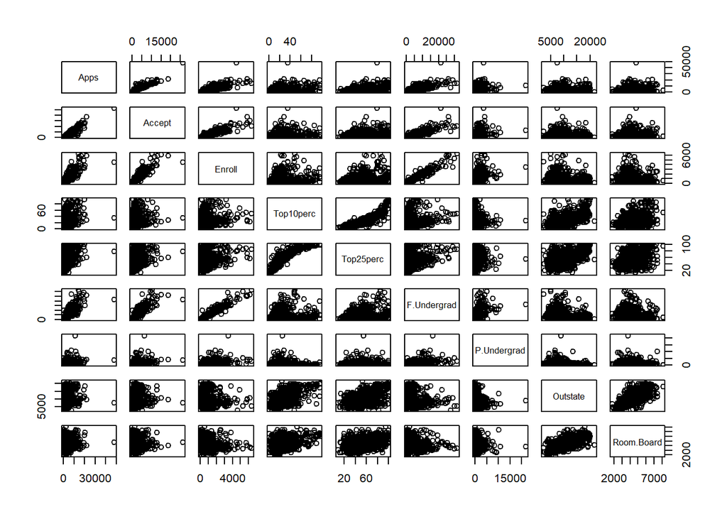

```r
#Scatterplot matrix
pairs(college[,2:10])
```

3. Use the `plot()` function to produce side-by-side boxplots of `Outstate` versus `Private`.

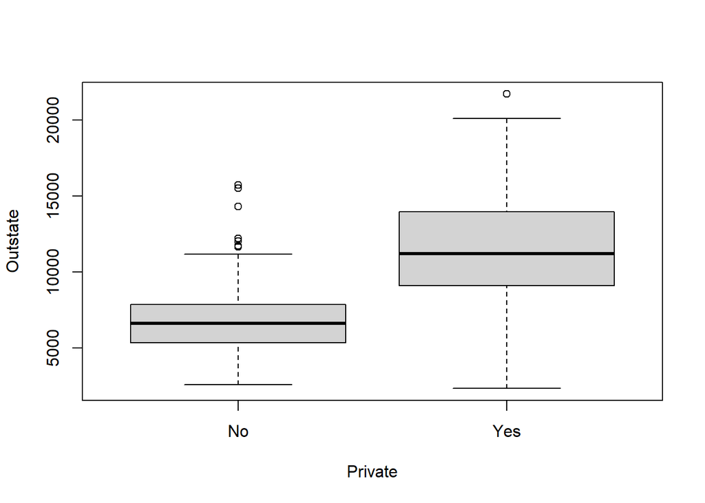

```r
#Boxplots
Outstate <- college$Outstate
Private <- college$Private
Name <- c("Outstate","Private")
boxplot(Outstate ~ Private, data = college)
```

4. Create a new qualitative variable, called `Elite`, by *binning* the `Top10perc` variable. We are going to divide universities into two groups based on whether or not the proportion of students coming from the top 10% of their high school classes exceeds 50%.

```r
#Creating the Elite variable
Elite <- rep("No", nrow(college))

#Mark "Yes" if >50% of the student coming from top 10% of their high school classes
Elite[college$Top10perc > 50] <- "Yes"

#Convert the Elite variable into numeric values
class(Elite) #The variable is of character type
```

```
## [1] "character"
```

```r
Elite <- as.factor(Elite) #Convert it into numeric

#Combine both together
college <- data.frame(college, Elite)
```

Use the `summary()` function to see how many elite universities there are. Now use the `plot()` function to produce side-by-side boxplots of `Outstate` versus `Elite`.

```r
summary(college$Elite)
```

```
##  No Yes
## 699  78
```

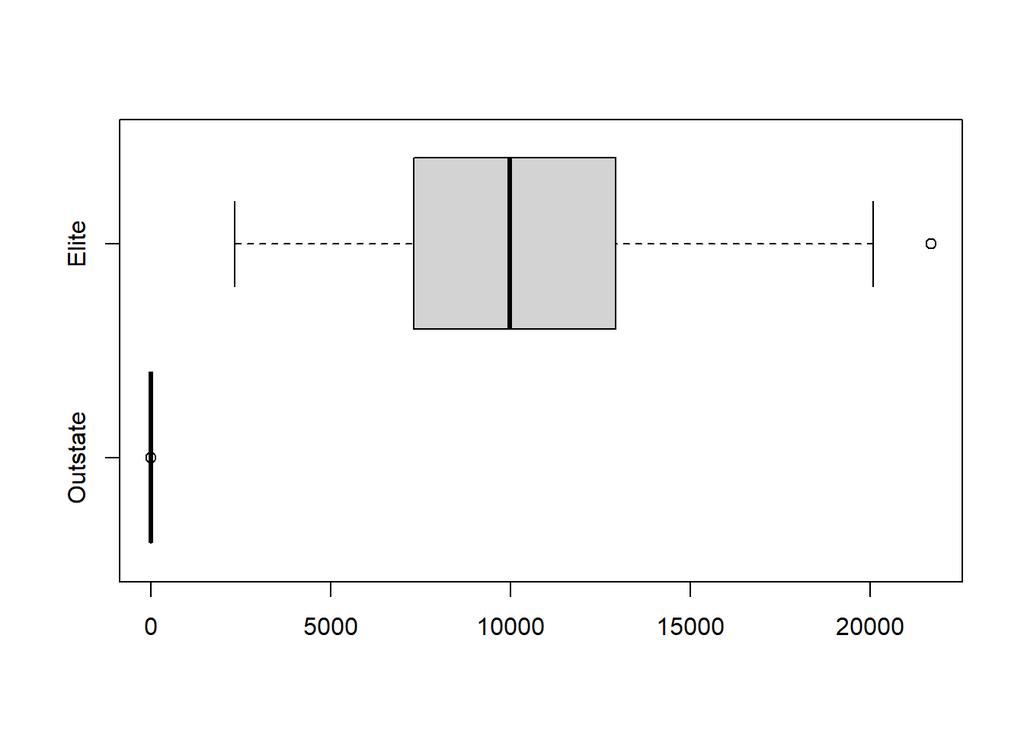

```r
Outstate <- college$Outstate
Elite1 <- college$Elite
Label <- c("Outstate","Elite")
boxplot(Elite, Outstate, names = Label,horizontal = TRUE)
```

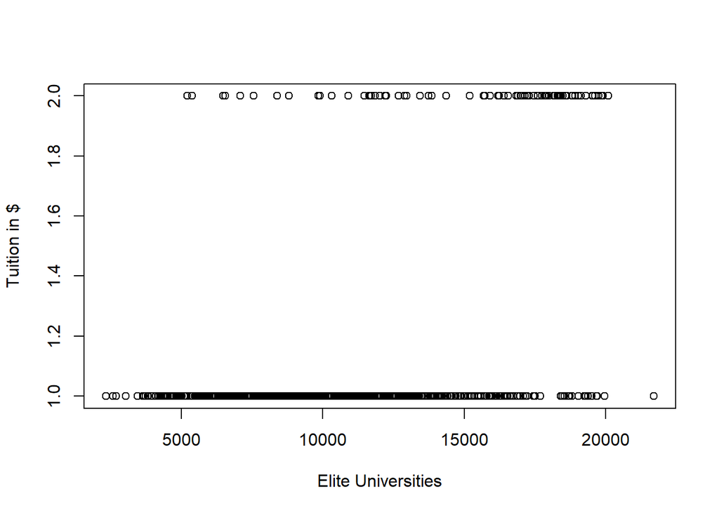

```r
plot(Outstate,Elite,xlab="Elite Universities",ylab="Tuition in $")
```

Continue exploring the data, and provide a brief summary of what you discover.

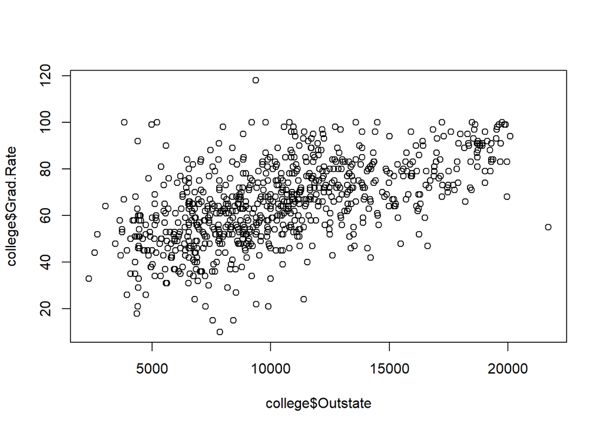

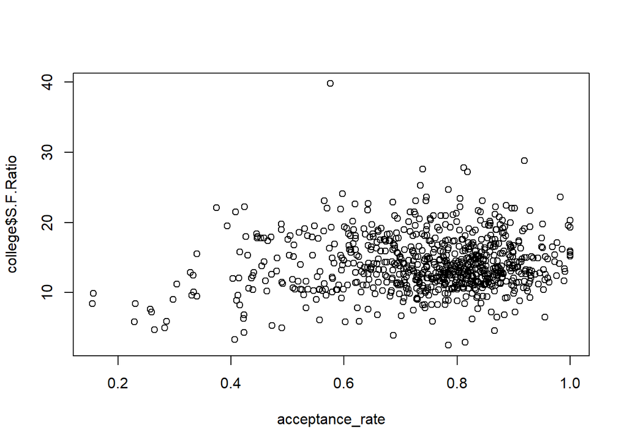

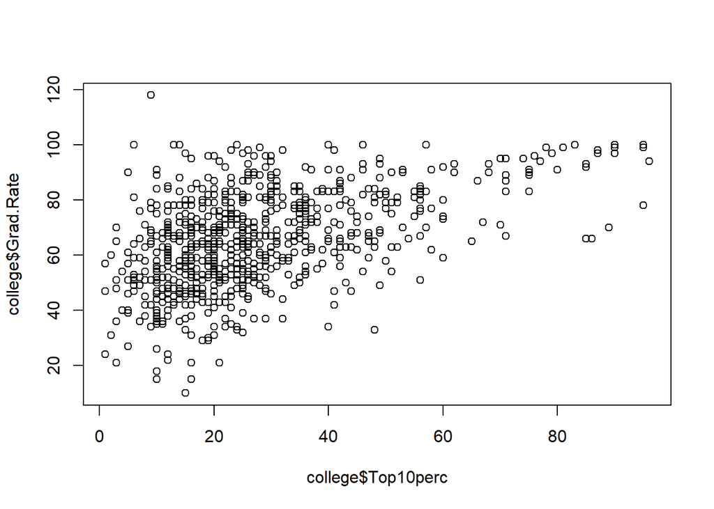

```r
View(College)

#Further exploration
acceptance_rate <- college$Accept / college$Apps

{
plot(college$Outstate,college$Grad.Rate)
plot(acceptance_rate, college$S.F.Ratio)
plot(college$Top10perc,college$Grad.Rate)
}
```

```r
{
cat(paste("College with the most students in the top 10% class: ", row.names(college)[which.max(college$Top10perc)], '\n'))
cat(paste("College with the lowest acceptance rate: ", row.names(college)[which.min(acceptance_rate)], '\n'))
cat(paste("College with the highest acceptance rate: ", row.names(college)[which.max(acceptance_rate)], '\n'))
cat(paste("College with the highest graduation rate: ", row.names(college)[which.max(college$Grad.Rate)], '\n'))
}
```

```
## College with the most students in the top 10% class:  Massachusetts Institute of Technology
## College with the lowest acceptance rate:  Princeton University
## College with the highest acceptance rate:  Emporia State University
## College with the highest graduation rate:  Cazenovia College
```

### 2. Working with the automotive dataset

This exercise involves the `Auto` data set available as `Auto.csv` from the website for the main course textbook James et al. http://faculty.marshall.usc.edu/gareth-james/ISL/data.html. Make sure that the missing values have been removed from the data. You should load that dataset as the first step of the exercise.

```r
#Load data
Auto <- read.csv("Auto.csv")

#Remove NA values
Auto <- na.omit(Auto)

#Summary statistics
summary(Auto)
```

```
##       mpg          cylinders      displacement     horsepower        weight
##  Min.   : 9.00   Min.   :3.000   Min.   : 68.0   Min.   : 46.0   Min.   :1613
##  1st Qu.:17.00   1st Qu.:4.000   1st Qu.:105.0   1st Qu.: 75.0   1st Qu.:2225
##  Median :22.75   Median :4.000   Median :151.0   Median : 93.5   Median :2804
##  Mean   :23.45   Mean   :5.472   Mean   :194.4   Mean   :104.5   Mean   :2978
##  3rd Qu.:29.00   3rd Qu.:8.000   3rd Qu.:275.8   3rd Qu.:126.0   3rd Qu.:3615
##  Max.   :46.60   Max.   :8.000   Max.   :455.0   Max.   :230.0   Max.   :5140
##   acceleration        year           origin          name
##  Min.   : 8.00   Min.   :70.00   Min.   :1.000   Length:392
##  1st Qu.:13.78   1st Qu.:73.00   1st Qu.:1.000   Class :character
##  Median :15.50   Median :76.00   Median :1.000   Mode  :character
##  Mean   :15.54   Mean   :75.98   Mean   :1.577
##  3rd Qu.:17.02   3rd Qu.:79.00   3rd Qu.:2.000
##  Max.   :24.80   Max.   :82.00   Max.   :3.000
```

1. Which of the predictors are quantitative, and which are qualitative? **Quantitative - mpg, cylinder, displacement, horsepower, weight, acceleration, year.** **Qualitative - origin, Name.**
2. What is the *range* of each quantitative predictor? You can answer this using the `range()` function.

```r
#Excluding quantitative variables
Auto1 <- Auto[,-c(8:9)]

apply(Auto1, 2, range)
```

```
##       mpg cylinders displacement horsepower weight acceleration year
## [1,]  9.0         3           68         46   1613          8.0   70
## [2,] 46.6         8          455        230   5140         24.8   82
```

3. What is the mean and standard deviation of each quantitative predictor?

```r
mean<- apply(Auto1, 2, mean)
sd <- apply(Auto1, 2, sd)

cbind(mean = mean, sd = sd)
```

```
##                     mean         sd
## mpg            23.445918   7.805007
## cylinders       5.471939   1.705783
## displacement  194.411990 104.644004
## horsepower    104.469388  38.491160
## weight       2977.584184 849.402560
## acceleration   15.541327   2.758864
## year           75.979592   3.683737
```

4. Now remove the 10th through 85th observations. What is the range, mean, and standard deviation of each predictor in the subset of the data that remains?

```r
Auto2 <- Auto1[-c(10:85),]

range <- apply(Auto2, 2, range)
mean <- apply(Auto2, 2, mean)
sd <- apply(Auto2, 2, sd)

tbl <- rbind(range, mean, sd)
rownames(tbl) <- c("Min", "Max", "Mean", "sd")
tbl
```

```
##            mpg cylinders displacement horsepower    weight acceleration
## Min  11.000000  3.000000     68.00000   46.00000 1649.0000     8.500000
## Max  46.600000  8.000000    455.00000  230.00000 4997.0000    24.800000
## Mean 24.404430  5.373418    187.24051  100.72152 2935.9715    15.726899
## sd    7.867283  1.654179     99.67837   35.70885  811.3002     2.693721
##           year
## Min  70.000000
## Max  82.000000
## Mean 77.145570
## sd    3.106217
```

5. Using the full data set, investigate the predictors graphically, using scatterplots or other tools of your choice. Create some plots highlighting the relationships among the predictors. Comment on your findings.

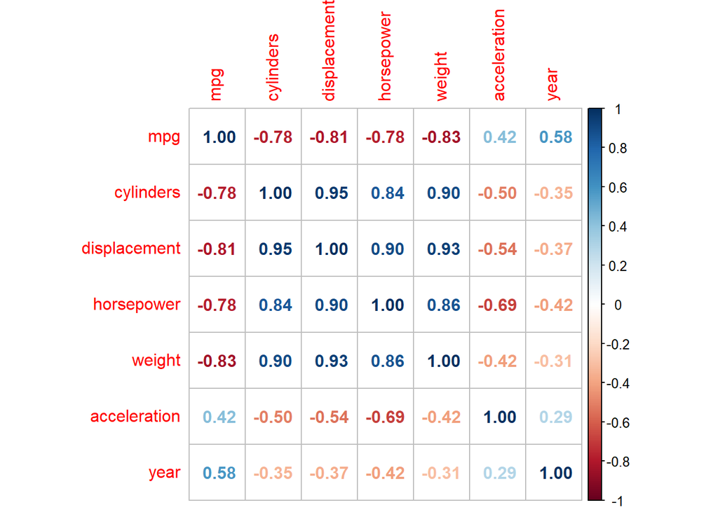

```r
#Use Auto1 as Auto1 excludes qualitative variables
library(purrr, quietly = TRUE)
library(corrplot, quietly = TRUE)
corr <- cor(Auto1) #Calculate correlation between variables
high_value <- apply(abs(corr) >= 0.8, 2, any) #Extract correlation greater than 0.8
corrplot(corr[high_value, high_value], method = "number") #plot variables with corr > 0.8
```

**The variable “mpg”, “displacement”, “cylinders”, “horsepower” and “weight” are highly correlated with each other.**

6. Suppose that we wish to predict gas mileage (`mpg`) on the basis of the other variables. Do your plots suggest that any of the other variables might be useful in predicting `mpg`? Justify your answer.

```r
#Prediction
Predict <- lm(mpg ~ cylinders+displacement+horsepower+weight+acceleration+year+origin, data=Auto)
summary(Predict)
```

```
##
## Call:
## lm(formula = mpg ~ cylinders + displacement + horsepower + weight +
##     acceleration + year + origin, data = Auto)
##
## Residuals:
##     Min      1Q  Median      3Q     Max
## -9.5903 -2.1565 -0.1169  1.8690 13.0604
##
## Coefficients:
##                Estimate Std. Error t value Pr(>|t|)
## (Intercept)  -17.218435   4.644294  -3.707  0.00024 ***
## cylinders     -0.493376   0.323282  -1.526  0.12780
## displacement   0.019896   0.007515   2.647  0.00844 **
## horsepower    -0.016951   0.013787  -1.230  0.21963
## weight        -0.006474   0.000652  -9.929  < 2e-16 ***
## acceleration   0.080576   0.098845   0.815  0.41548
## year           0.750773   0.050973  14.729  < 2e-16 ***
## origin         1.426141   0.278136   5.127 4.67e-07 ***
## ---
## Signif. codes:  0 '***' 0.001 '**' 0.01 '*' 0.05 '.' 0.1 ' ' 1
##
## Residual standard error: 3.328 on 384 degrees of freedom
## Multiple R-squared:  0.8215, Adjusted R-squared:  0.8182
## F-statistic: 252.4 on 7 and 384 DF,  p-value: < 2.2e-16
```

**The t-values suggests “displacement”, “weight”, “year” and “origin” are significant in predicting “mpg”. The remaining variables are not significant in predicting the model.**

```r
fit <- lm(mpg ~ displacement+weight+year+origin, data=Auto)
summary(fit)
```

```
##
## Call:
## lm(formula = mpg ~ displacement + weight + year + origin, data = Auto)
##
## Residuals:
##     Min      1Q  Median      3Q     Max
## -9.8102 -2.1129 -0.0388  1.7725 13.2085
##
## Coefficients:
##                Estimate Std. Error t value Pr(>|t|)
## (Intercept)  -1.861e+01  4.028e+00  -4.620 5.25e-06 ***
## displacement  5.588e-03  4.768e-03   1.172    0.242
## weight       -6.575e-03  5.571e-04 -11.802  < 2e-16 ***
## year          7.714e-01  4.981e-02  15.486  < 2e-16 ***
## origin        1.226e+00  2.670e-01   4.593 5.92e-06 ***
## ---
## Signif. codes:  0 '***' 0.001 '**' 0.01 '*' 0.05 '.' 0.1 ' ' 1
##
## Residual standard error: 3.346 on 387 degrees of freedom
## Multiple R-squared:  0.8181, Adjusted R-squared:  0.8162
## F-statistic: 435.1 on 4 and 387 DF,  p-value: < 2.2e-16
```

### Further materials

- [Data Camp R tutorials](https://www.datacamp.com/courses/free-introduction-to-r)
- [Data Camp R Markdown tutorials](https://www.datacamp.com/courses/reporting-with-r-markdown). You can complete the free first chapter.